# Rogers_HW7

#### d.

Prior Beta(8, 3) Posterior Beta(15, 6)

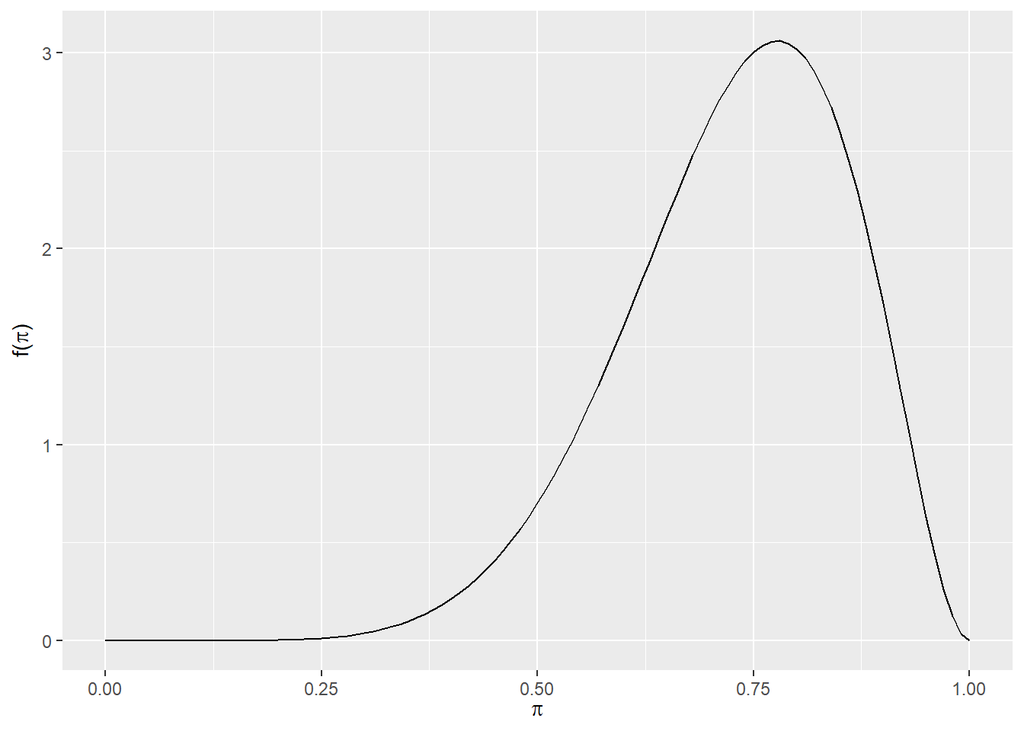

```r
plot_beta(8, 3)
```

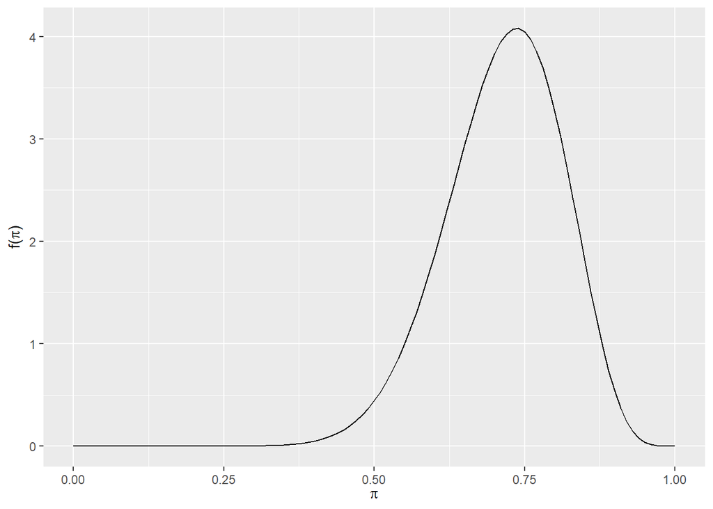

```r
plot_beta(15, 6)
```

So the data basically aligned with our prior suspicions

I don’t think the data here have to be a large sample, just in line with the prior

```r
summarize_beta_binomial(8, 3, 7, 10)
```

```
##       model alpha beta      mean      mode         var         sd
## 1     prior     8    3 0.7272727 0.7777778 0.016528926 0.12856487
## 2 posterior    15    6 0.7142857 0.7368421 0.009276438 0.09631427
```

Looking for posterior (15, 6) y = 5 n = 8 gives me Posterior Beta (13, 6) y = 6 n = 8 gives me Posterior Beta (14, 5)

I don’t think you can have a partial success here so I’m confused.

Okay, played around with it some more, y = 7, n = 10 works.

I think I just confused myself. I was looking for mean ~ .75 instead of mean ~ .7

#### e.

Prior Beta (2, 2) Posterior Beta (5, 5)

Okay I think I can do this one almost first try. We definitely got a 50 / 50 success rate. We are not that much more convinced. I think this was like y = 2 n = 4

```r
summarize_beta_binomial(2, 2, 3, 6)
```

```
##       model alpha beta mean mode        var        sd
## 1     prior     2    2  0.5  0.5 0.05000000 0.2236068
## 2 posterior     5    5  0.5  0.5 0.02272727 0.1507557
```

Okay, second try. Still happy with my intuition.

#### f.

Prior Beta (1, 1) Posterior Beta (30, 3)

So we went from no idea to almost certain an event occurs. We have some very convincing data.

```r
summarize_beta_binomial(1, 1, 29, 31)
```

```
##       model alpha beta      mean      mode         var         sd
## 1     prior     1    1 0.5000000       NaN 0.083333333 0.28867513
## 2 posterior    30    3 0.9090909 0.9354839 0.002430724 0.04930238
```

Started at 99 of 100. Took about five guesses to tune.

##### (Different data, uninformative prior)

#### a.

10 of 13

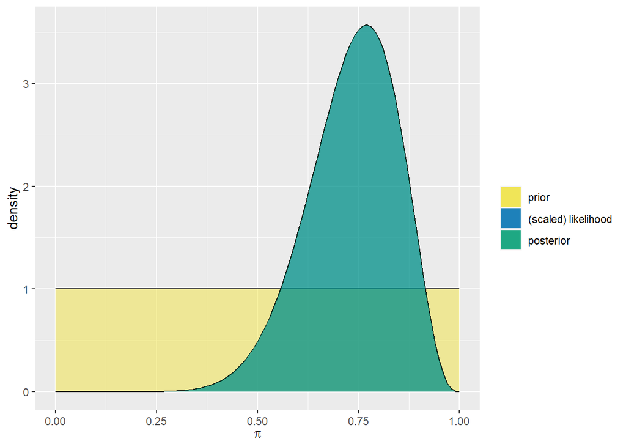

```r
plot_beta_binomial(1, 1, 10, 13)
```

```r
summarize_beta_binomial(1, 1, 10, 13)
```

```
##       model alpha beta      mean      mode        var        sd
## 1     prior     1    1 0.5000000       NaN 0.08333333 0.2886751
## 2 posterior    11    4 0.7333333 0.7692308 0.01222222 0.1105542
```

#### b.

0 of 1

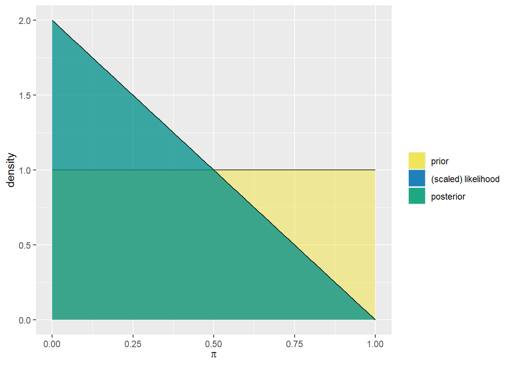

```r
plot_beta_binomial(1, 1, 0, 1)
```

```r
summarize_beta_binomial(1, 1, 0, 1)
```

```
##       model alpha beta      mean mode        var        sd
## 1     prior     1    1 0.5000000  NaN 0.08333333 0.2886751
## 2 posterior     1    2 0.3333333    0 0.05555556 0.2357023
```

Interesting representation. Since we had effectively no prior, the posterior and likelihood completely overlap even with almost no data observed.

#### c.

100 of 130

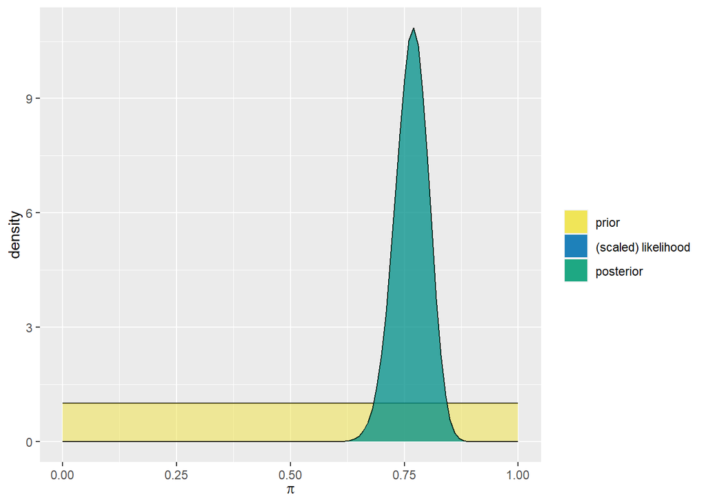

```r
plot_beta_binomial(1, 1, 100, 130)
```

```r
summarize_beta_binomial(1, 1, 100, 130)
```

```
##       model alpha beta      mean      mode         var         sd
## 1     prior     1    1 0.5000000       NaN 0.083333333 0.28867513
## 2 posterior   101   31 0.7651515 0.7692308 0.001351088 0.03675715
```

#### d.

20 of 120

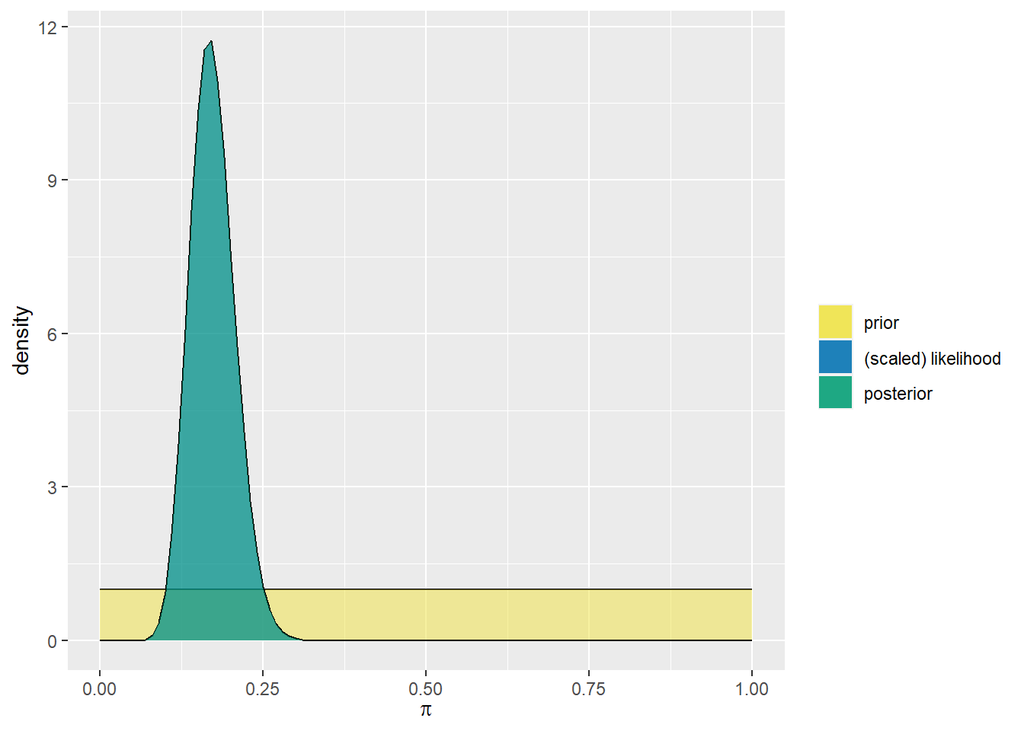

```r
plot_beta_binomial(1, 1, 20, 120)
```

```r
summarize_beta_binomial(1, 1, 20, 120)
```

```
##       model alpha beta      mean      mode         var         sd
## 1     prior     1    1 0.5000000       NaN 0.083333333 0.28867513
## 2 posterior    21  101 0.1721311 0.1666667 0.001158553 0.03403752
```

#### e.

234 of 468

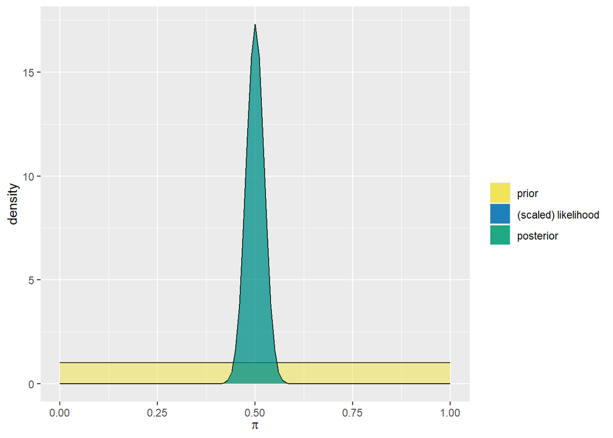

```r
plot_beta_binomial(1, 1, 234, 468)
```

```r
summarize_beta_binomial(1, 1, 234, 468)
```

```
##       model alpha beta mean mode          var         sd
## 1     prior     1    1  0.5  NaN 0.0833333333 0.28867513
## 2 posterior   235  235  0.5  0.5 0.0005307856 0.02303878
```

##### 4.12 (Different data, informative prior)

10 of 13

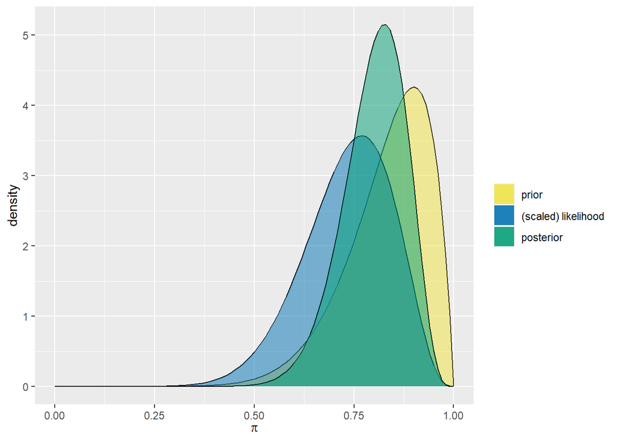

```r
plot_beta_binomial(10, 2, 10, 13)
```

```r
summarize_beta_binomial(10, 2, 10, 13)
```

```
##       model alpha beta      mean     mode         var         sd
## 1     prior    10    2 0.8333333 0.900000 0.010683761 0.10336228
## 2 posterior    20    5 0.8000000 0.826087 0.006153846 0.07844645
```

#### b.

0 of 1

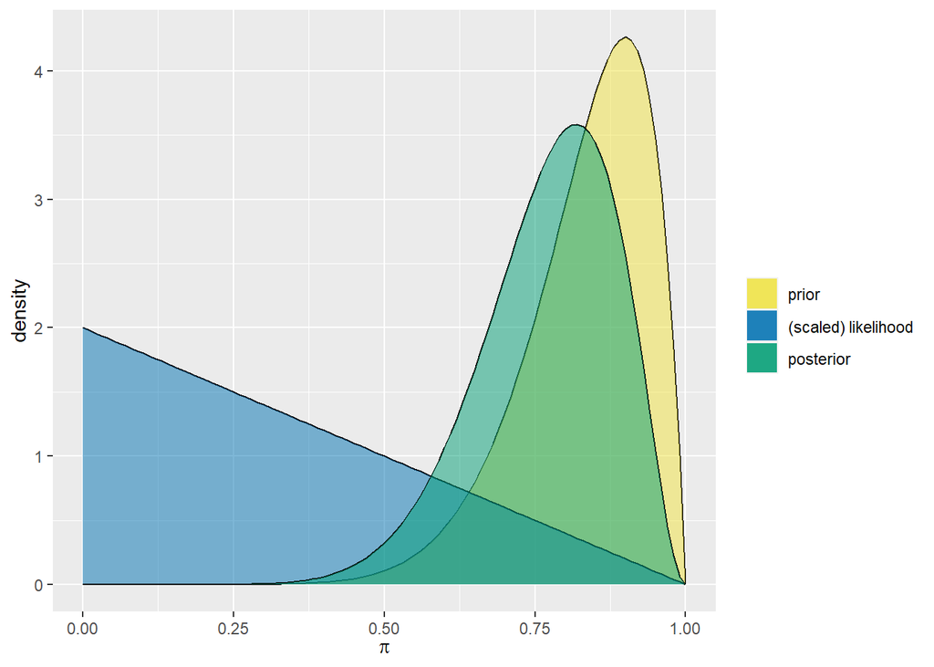

```r
plot_beta_binomial(10, 2, 0, 1)
```

```r
summarize_beta_binomial(10, 2, 0, 1)
```

```
##       model alpha beta      mean      mode        var        sd
## 1     prior    10    2 0.8333333 0.9000000 0.01068376 0.1033623
## 2 posterior    10    3 0.7692308 0.8181818 0.01267963 0.1126039
```

#### c.

100 of 130

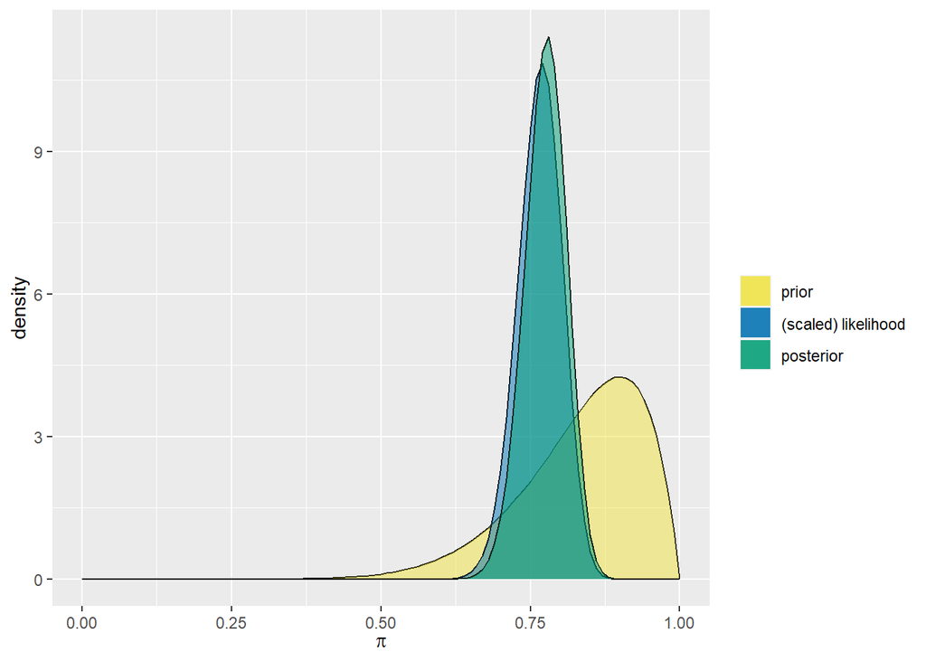

```r
plot_beta_binomial(10, 2, 100, 130)
```

```r
summarize_beta_binomial(10, 2, 100, 130)
```

```
##       model alpha beta      mean      mode         var         sd
## 1     prior    10    2 0.8333333 0.9000000 0.010683761 0.10336228
## 2 posterior   110   32 0.7746479 0.7785714 0.001220759 0.03493936
```

#### d.

20 of 120

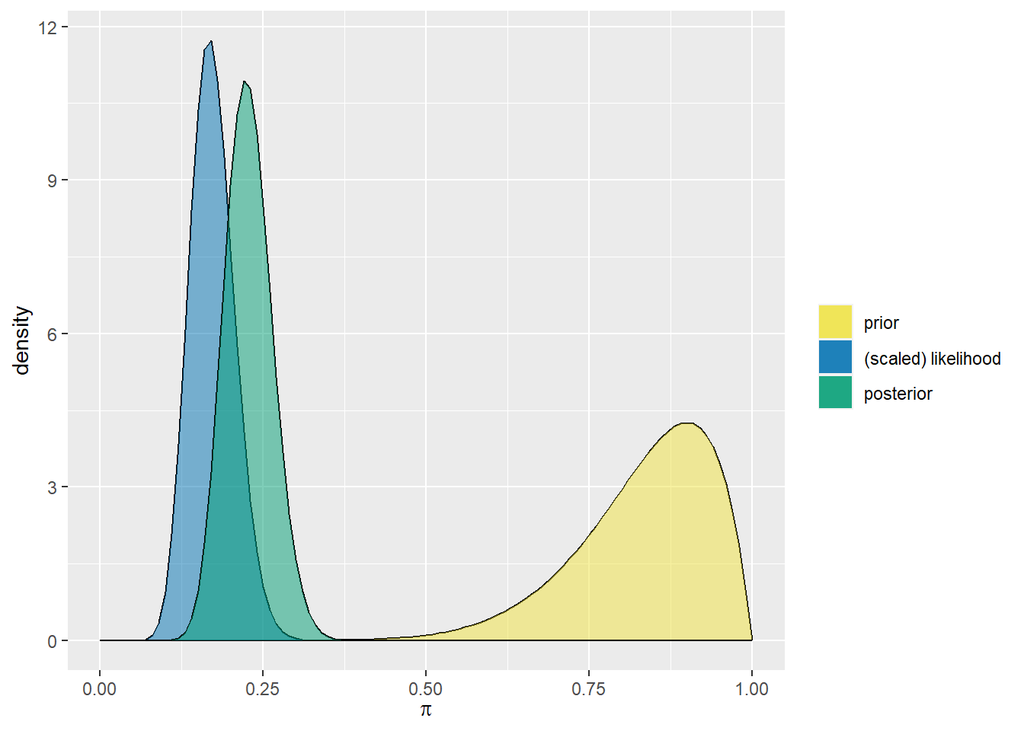

```r
plot_beta_binomial(10, 2, 20, 120)
```

```r
summarize_beta_binomial(10, 2, 20, 120)
```

```
##       model alpha beta      mean      mode        var        sd
## 1     prior    10    2 0.8333333 0.9000000 0.01068376 0.1033623
## 2 posterior    30  102 0.2272727 0.2230769 0.00132045 0.0363380
```

#### e.

234 of 468

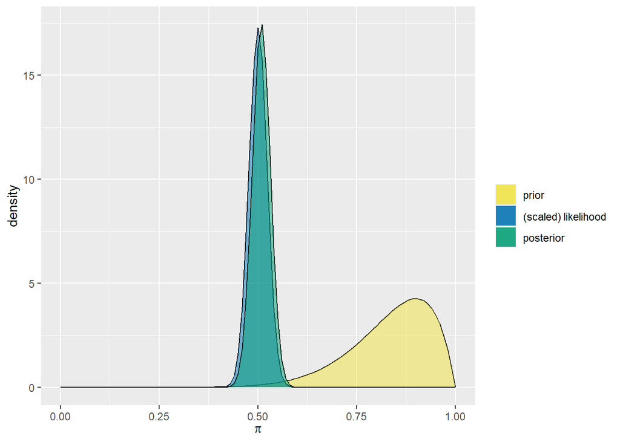

```r
plot_beta_binomial(10, 2, 234, 468)
```

```r
summarize_beta_binomial(10, 2, 234, 468)
```

```
##       model alpha beta      mean      mode          var         sd
## 1     prior    10    2 0.8333333 0.9000000 0.0106837607 0.10336228
## 2 posterior   244  236 0.5083333 0.5083682 0.0005196061 0.02279487
```

### 4.9.4 Practice: Sequentiality

##### Exercise 4.15 (One at a time)

Prior Beta (2, 3)

#### a.

```r
summarize_beta_binomial(2, 3, 1, 1)
```

```
##       model alpha beta mean      mode        var        sd
## 1     prior     2    3  0.4 0.3333333 0.04000000 0.2000000
## 2 posterior     3    3  0.5 0.5000000 0.03571429 0.1889822
```

#### b.

```r
summarize_beta_binomial(3, 3, 1, 1)
```

```
##       model alpha beta      mean mode        var        sd
## 1     prior     3    3 0.5000000  0.5 0.03571429 0.1889822
## 2 posterior     4    3 0.5714286  0.6 0.03061224 0.1749636
```

#### c.

```r
summarize_beta_binomial(4, 3, 0, 1)
```

```
##       model alpha beta      mean mode        var        sd
## 1     prior     4    3 0.5714286  0.6 0.03061224 0.1749636
## 2 posterior     4    4 0.5000000  0.5 0.02777778 0.1666667
```

#### d.

```r
summarize_beta_binomial(4, 4, 1, 1)
```

```
##       model alpha beta      mean      mode        var        sd
## 1     prior     4    4 0.5000000 0.5000000 0.02777778 0.1666667
## 2 posterior     5    4 0.5555556 0.5714286 0.02469136 0.1571348
```

##### Exercise 4.16 (Five at a time)

So I realized as I was doing this I was doing it wrong. I didn’t notice it in 4.15 because the observations were small, but in this exercise my posterior was growing much faster than made sense. I was including the data from the previous observations, instead of just sequentially updating the Beta (e.g. for part b. I had Beta(5, 5) and data y = 4 n = 10)

#### a.

```r
summarize_beta_binomial(2, 3, 3, 5)
```

```
##       model alpha beta mean      mode        var        sd
## 1     prior     2    3  0.4 0.3333333 0.04000000 0.2000000
## 2 posterior     5    5  0.5 0.5000000 0.02272727 0.1507557
```

#### b.

```r
summarize_beta_binomial(5, 5, 1, 5)
```

```
##       model alpha beta mean      mode        var        sd
## 1     prior     5    5  0.5 0.5000000 0.02272727 0.1507557
## 2 posterior     6    9  0.4 0.3846154 0.01500000 0.1224745
```

#### c.

```r
summarize_beta_binomial(6, 9, 1, 5)
```

```
##       model alpha beta mean      mode        var        sd
## 1     prior     6    9 0.40 0.3846154 0.01500000 0.1224745
## 2 posterior     7   13 0.35 0.3333333 0.01083333 0.1040833
```

#### d.

```r
summarize_beta_binomial(7, 13, 2, 5)
```

```
##       model alpha beta mean      mode         var         sd
## 1     prior     7   13 0.35 0.3333333 0.010833333 0.10408330
## 2 posterior     9   16 0.36 0.3478261 0.008861538 0.09413574
```

##### Exercise 4.17 (Different data, different posteriors)

#### a.

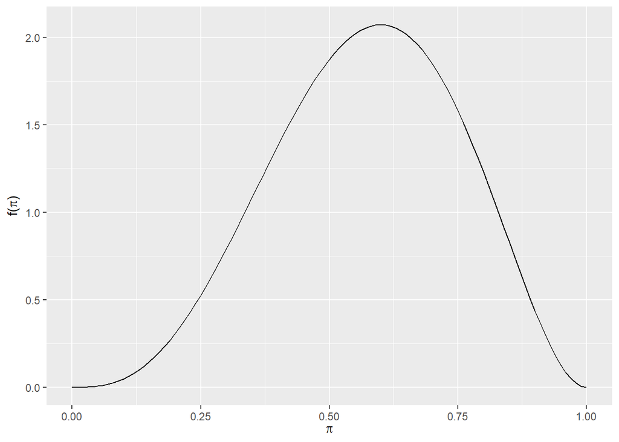

```r
plot_beta(4, 3)
```

The employees think it is more likely than not that people will click the ad, but they’re not very sure at all.They might say between 25% and 80% of people will click the ad.

#### b.

Prior Beta(4, 3)

y = 0, N = 1

```r
summarize_beta_binomial(4, 3, 0 , 1)
```

```
##       model alpha beta      mean mode        var        sd
## 1     prior     4    3 0.5714286  0.6 0.03061224 0.1749636
## 2 posterior     4    4 0.5000000  0.5 0.02777778 0.1666667
```

Prior Beta(4, 3)

y = 3, N = 10

```r
summarize_beta_binomial(4, 3, 3, 10)
```

```
##       model alpha beta      mean mode        var        sd
## 1     prior     4    3 0.5714286  0.6 0.03061224 0.1749636
## 2 posterior     7   10 0.4117647  0.4 0.01345636 0.1160016
```

Prior Beta(4, 3)

y = 20, n = 100

```r
summarize_beta_binomial(4, 3, 20, 100)
```

```
##       model alpha beta      mean      mode         var         sd
## 1     prior     4    3 0.5714286 0.6000000 0.030612245 0.17496355
## 2 posterior    24   83 0.2242991 0.2190476 0.001611009 0.04013738
```

#### c.

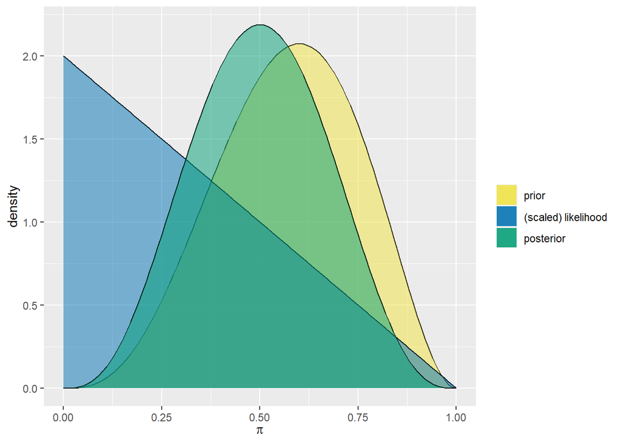

```r
plot_beta_binomial(4, 3, 0, 1)
```

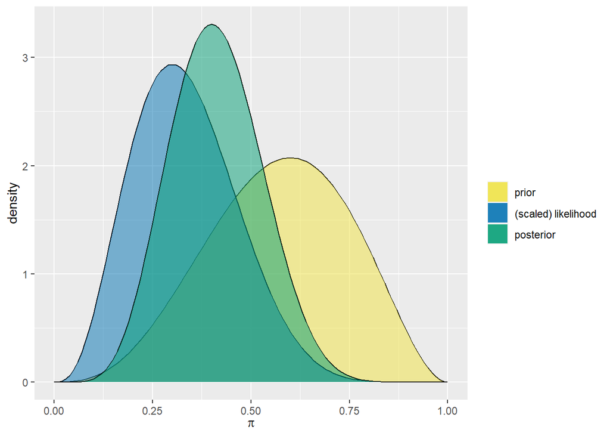

```r
plot_beta_binomial(4, 3, 3, 10)
```

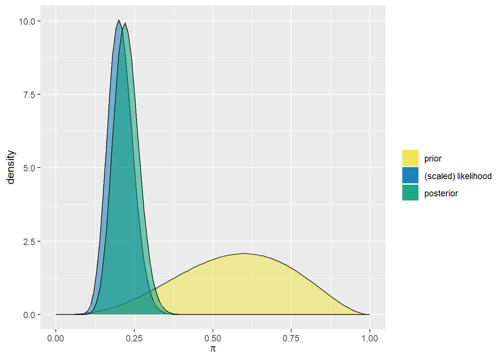

```r
plot_beta_binomial(4, 3, 20, 100)
```

#### d.

I think I already did this in part b… thinking I did something wrong now. Going to check back later

It’s honestly still not clear to me what was expected in part b

##### Exercise 4.18 (A sequential employee)

#### a.

Day one

```r
summarize_beta_binomial(4, 3, 0, 1)
```

```
##       model alpha beta      mean mode        var        sd
## 1     prior     4    3 0.5714286  0.6 0.03061224 0.1749636
## 2 posterior     4    4 0.5000000  0.5 0.02777778 0.1666667
```

Day two

```r
summarize_beta_binomial(4, 4, 3, 10)
```

```
##       model alpha beta      mean  mode        var        sd
## 1     prior     4    4 0.5000000 0.500 0.02777778 0.1666667
## 2 posterior     7   11 0.3888889 0.375 0.01250812 0.1118397
```

Day three

```r
summarize_beta_binomial(7, 11, 20, 100)
```

```
##       model alpha beta      mean      mode        var         sd
## 1     prior     7   11 0.3888889 0.3750000 0.01250812 0.11183972
## 2 posterior    27   91 0.2288136 0.2241379 0.00148284 0.03850766
```

#### b.

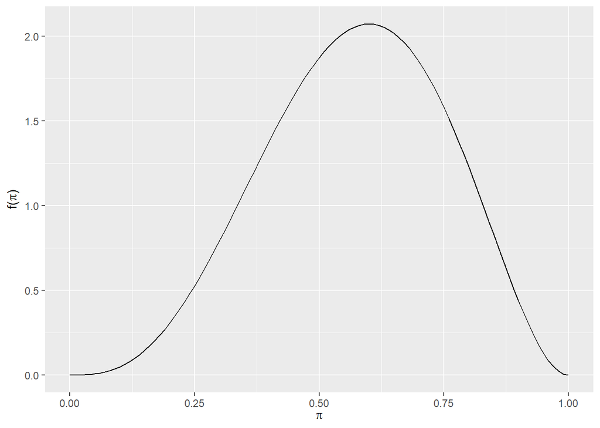

```r
# initial prior
plot_beta(4, 3)
```

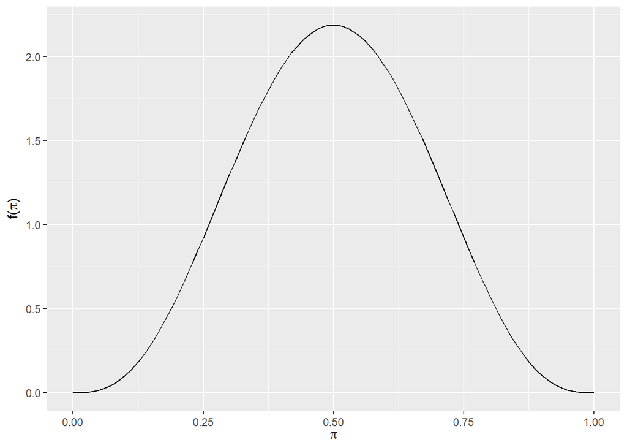

```r
# first posterior
plot_beta(4, 4)
```

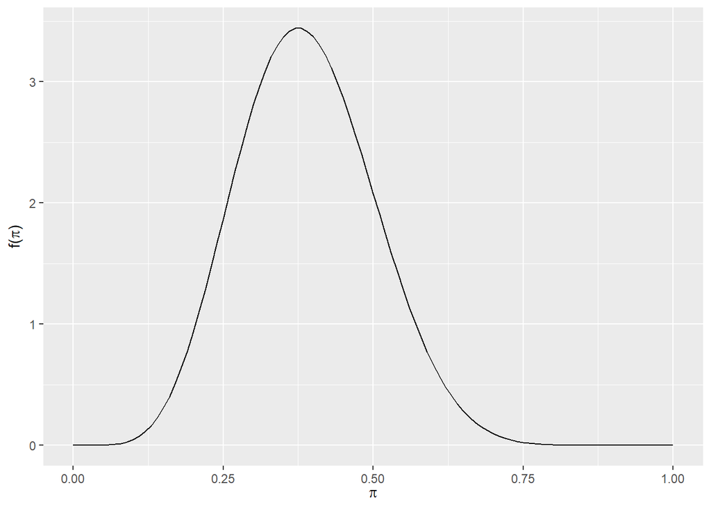

```r
# second posterior
plot_beta(7, 11)
```

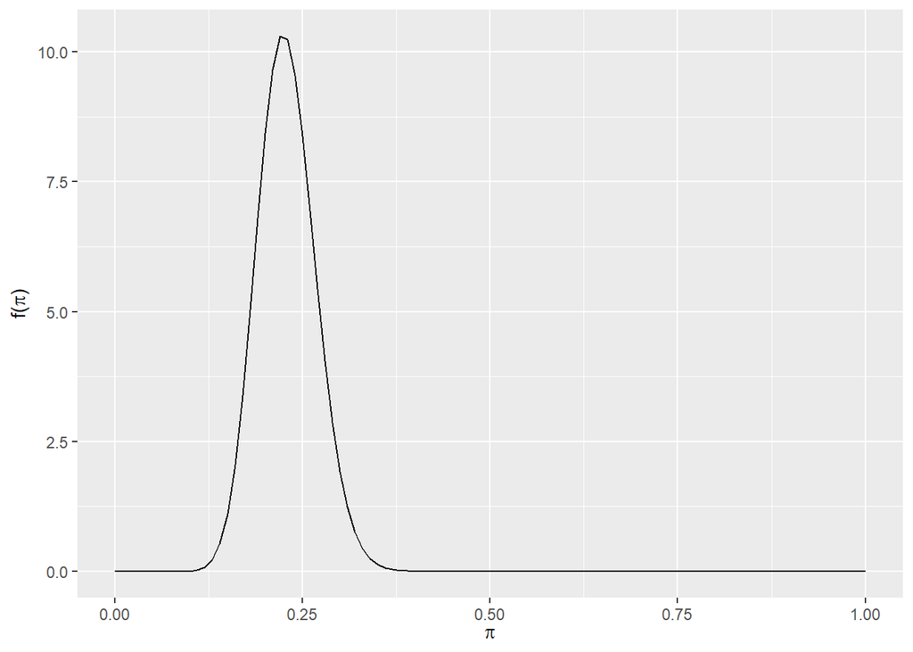

```r
# third posterior
plot_beta(27, 91)
```

On the first day their understanding didn’t change much at all. This makes sense given they didn’t have much data at all to compare to the prior.

On the second day they adjusted their understanding a bit. They got a bit more confident in the model, but still left a lot of room for change, basically waiting for a significant sample.

On day three as a result of a large sample the employee really became confident in their estimate.

#### c.

```r
summarize_beta_binomial(4, 3, 23, 111)
```

```
##       model alpha beta      mean      mode        var         sd
## 1     prior     4    3 0.5714286 0.6000000 0.03061224 0.17496355
## 2 posterior    27   91 0.2288136 0.2241379 0.00148284 0.03850766
```

As expected, this is the same as when the data is included in the model sequentially. This makes sense!

##### Exercise 4.19 (Bechdel test)

#### a.

```r
b1980 <- filter(bechdel, year == "1980")
nrow(b1980)
```

```
## [1] 14
```

```r
pass1980 <- filter(b1980, binary == "PASS")
nrow(pass1980)
```

```
## [1] 4
```

```r
summarize_beta_binomial(1, 1, 4, 14)
```

```
##       model alpha beta   mean      mode        var        sd
## 1     prior     1    1 0.5000       NaN 0.08333333 0.2886751
## 2 posterior     5   11 0.3125 0.2857143 0.01263787 0.1124183
```

#### b.

```r
b1990 <- filter(bechdel, year == "1990")
nrow(b1990)
```

```
## [1] 15
```

```r
pass1990 <- filter(b1990, binary == "PASS")
nrow(pass1990)
```

```
## [1] 6
```

```r
summarize_beta_binomial(5, 11, 6, 15)
```

```
##       model alpha beta      mean      mode         var         sd
## 1     prior     5   11 0.3125000 0.2857143 0.012637868 0.11241827
## 2 posterior    11   20 0.3548387 0.3448276 0.007154006 0.08458136
```

#### c.

```r
b2000 <- filter(bechdel, year == "2000")
nrow(b2000)
```

```
## [1] 63
```

```r
pass2000 <- filter(b2000, binary == "PASS")
nrow(pass2000)
```

```
## [1] 29
```

```r
summarize_beta_binomial(11, 20, 29, 63)
```

```
##       model alpha beta      mean      mode         var         sd
## 1     prior    11   20 0.3548387 0.3448276 0.007154006 0.08458136
## 2 posterior    40   54 0.4255319 0.4239130 0.002573205 0.05072677
```

#### d.

```r
nrow(pass1980) + nrow(pass1990) + nrow(pass2000)
```

```
## [1] 39
```

```r
nrow(b1980) + nrow(b1990) + nrow(b2000)
```

```
## [1] 92
```

```r
summarize_beta_binomial(1, 1, 29, 63)
```

```
##       model alpha beta      mean      mode         var         sd
## 1     prior     1    1 0.5000000       NaN 0.083333333 0.28867513
## 2 posterior    30   35 0.4615385 0.4603175 0.003765465 0.06136339
```

Okay so this doesn’t work but I’m not sure why… trying something different.

```r
bfinal <- filter(bechdel, (year == "1980" | year == "1990" | year == "2000"))
nrow(bfinal)
```

```
## [1] 92
```

```r
bfinalpass <- filter(bfinal, binary == "PASS")
nrow(bfinalpass)
```

```
## [1] 39
```

```r
summarize_beta_binomial(1, 1, 39, 92)
```

```
##       model alpha beta      mean     mode         var         sd
## 1     prior     1    1 0.5000000      NaN 0.083333333 0.28867513
## 2 posterior    40   54 0.4255319 0.423913 0.002573205 0.05072677
```

Cool, so that matches the posterior from part c. Not sure if I had an arithmetic error or what.

Okay I went back through and I just straight up put the wrong numbers in. But I did learn how to filter by multiple variable outcomes using | as a result so that’s nice.

##### Exercise 4.20 (Bayesian and frequentist: sequential edition)

This Bayesian approach is different from a frequentest approach because a set of new outcomes is balanced with our prior knowledge and prior outcomes. The Bayesian approach allows us to include not only prior results, but prior intuition about how the world works.

The Bayesian approach is similar to the frequentest approach in that they both benefit from large samples to better quantify our uncertainty.